# Predicting Boston Housing Prices:

[figure not shown]

- **0. Introduction**
- **I. Data Exploration**
- **II. Developping a Model**
- **III. Analyzing Model Performance**
- **IV. Searching for the Optimal Model**
- **V. Conclusion**

# 0. Introduction:

In this project, we will evaluate the performance and predictive power of a model that has been trained and tested on data collected from homes in suburbs of Boston, Massachusetts. A model trained on this data that is seen as a *good fit* could then be used to make certain predictions about a home — in particular, its monetary value.

The dataset for this project originates from the [UCI Machine Learning Repository](https://archive.ics.uci.edu/ml/datasets/Housing). The Boston housing data was collected in 1978 and each of the 506 entries represent aggregated data about 14 features for homes from various suburbs in Boston, Massachusetts.

For the purposes of this project, the following preprocessing steps have been made to the dataset:

- 16 data points have an `'MEDV'` value of 50.0. These data points likely contain **missing or censored values** and have been removed.
- 1 data point has an `'RM'` value of 8.78. This data point can be considered an **outlier** and has been removed.
- The features `'RM'`, `'LSTAT'`, `'PTRATIO'`, and `'MEDV'` are essential. The remaining **non-relevant features** have been excluded.
- The feature `'MEDV'` has been **multiplicatively scaled** to account for 35 years of market inflation.

## *Importing Necessary libraries*

```python
# Import libraries necessary for this project

import numpy as np # import numpy library labeled as np
import pandas as pd # import pandas library labeled as pd

# Import pyplot from matplotlib to draw visualizations
import matplotlib.pyplot as plt

# Import Seaborn for better plots
import seaborn as sns

# Pretty display for notebooks
%matplotlib inline

# Display inline matplotlib plots with IPython
from IPython import get_ipython
get_ipython().run_line_magic('matplotlib', 'inline')

# Import 'r2_score'
from sklearn.metrics import r2_score

# Import 'train_test_split'
from sklearn.cross_validation import train_test_split

# Import ShuffleSplit
from sklearn.cross_validation import ShuffleSplit

# import the Decision Tree Regressor
from sklearn.tree import DecisionTreeRegressor

# Import learning curves package
import sklearn.learning_curve as curves

# Import 'make_scorer' and 'GridSearchCV'
from sklearn.grid_search import GridSearchCV
from sklearn. metrics import make_scorer
```

We'll start with the reading in the data, and separating the features and prices for homes into different pandas dataframes.

```python
# Load the Boston housing dataset
data = pd.read_csv('housing.csv')
prices = data['MEDV']
features = data.drop('MEDV', axis = 1)

# Success
print "Boston housing dataset has {} data points with {} variables each.".format(*data.shape)
```

```
Boston housing dataset has 489 data points with 4 variables each.
```

# I. Data Exploration

In the first section of this project, We will make a cursory investigation about the Boston housing data and provide some observations.

Since the main goal of this project is to construct a working model which has the capability of predicting the value of houses, we will need to separate the dataset into **features** and the **target variable**. The **features**, `'RM'`, `'LSTAT'`, and `'PTRATIO'`, give us quantitative information about each data point. The **target variable**, `'MEDV'`, will be the variable we seek to predict. These are stored in `features` and `prices`, respectively.

### Calculating Statistics:

We will start with calculating some descriptive statistics about the Boston housing prices using **`numpy`** library. These statistics will be extremely important later on to analyze various prediction results from the constructed model.

We will Calculate the minimum, maximum, mean, median, and standard deviation of the target variable **`'MEDV'`**, which is stored in **`prices`**.

```python
# Minimum price of the data
minimum_price = np.min(prices)

# Maximum price of the data
maximum_price = np.max(prices)

# Mean price of the data
mean_price = np.mean(prices)

# Median price of the data
median_price = np.median(prices)

# Standard deviation of prices of the data
std_price = np.std(prices)

# Show the calculated statistics
print "Statistics for Boston housing dataset:\n"
print "Minimum price: ${:,.2f}".format(minimum_price)
print "Maximum price: ${:,.2f}".format(maximum_price)
print "Mean price: ${:,.2f}".format(mean_price)
print "Median price ${:,.2f}".format(median_price)
print "Standard deviation of prices: ${:,.2f}".format(std_price)
```

```
Statistics for Boston housing dataset:

Minimum price: $105,000.00
Maximum price: $1,024,800.00
Mean price: $454,342.94
Median price $438,900.00
Standard deviation of prices: $165,171.13
```

### Feature Observation

As a reminder, we are using three features from the Boston housing dataset: `'RM'`, `'LSTAT'`, and `'PTRATIO'`.

For each data point:

- `'RM'` is the average number of rooms among homes in the neighborhood.
- `'LSTAT'` is the percentage of homeowners in the neighborhood considered "lower class" (working poor).
- `'PTRATIO'` is the ratio of students to teachers in primary and secondary schools in the neighborhood.

Before start building predictive models, let's try to figure out the different correlations between each **feature** and **the target variable**.

- **'RM':** An increase in the`'RM'` value(number of rooms) will lead to an increase in the value of 'MEDV'. This is because for you'd expect a home with a higher number of rooms to be more expensive than a home with lower number of rooms. The 'RM' is **positively corrrelated** with the house prices' .
- **'LSTAT':** The feature 'LSTAT' represents the percentage of homeowners in the neighborhood considered "lower class" as mentioned earlier. So these people of lower class generally wouldn't tend to buy expensive houses. They will search for cheaper ones. As a result in a neighborhood with a low 'LSTAT' value house selling prices will be more expensive than ones in a neighborhood with higher 'LSTAT' value. `'LSTAT'` is **negatively correlated** with `house prices`.
- **'PTRATIO':** Families tend to buy a houses in neighborhoods having a low 'PTRATIO' (ratio of students to teachers) to assure the best teaching quality to their children. So, I expect home selling prices' of a neighborhood that has a low 'PTRATIO' value to be more expensive than a neighborhood with a higher 'PTRATIO' value .

The scatter plots bellow confirm our intuitive expectations to be correct.

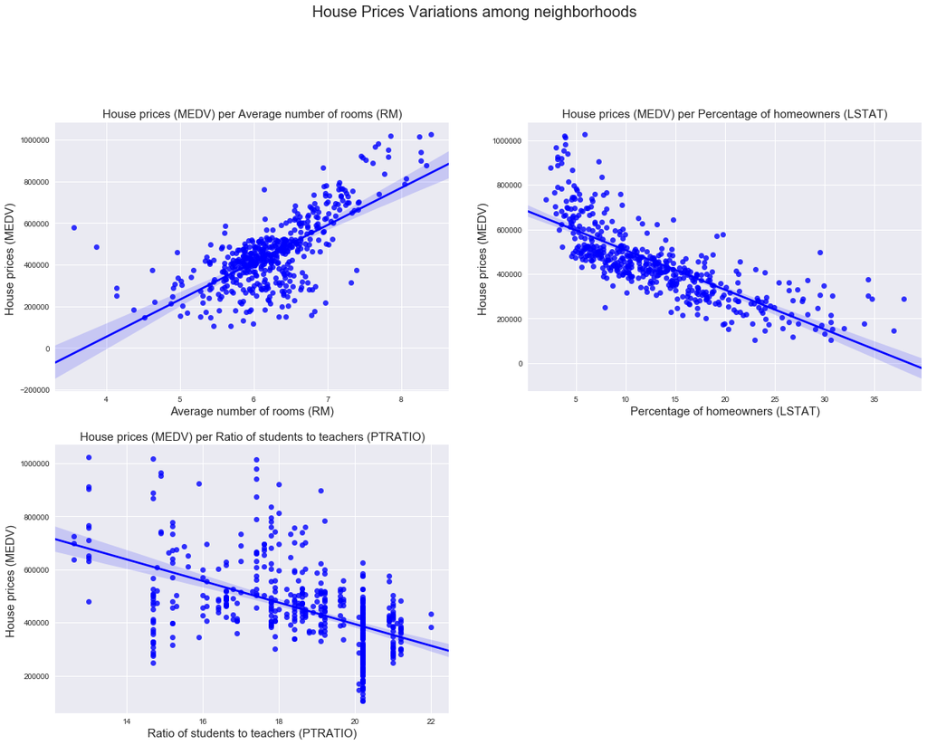

```python
# axis labels
features_titles= {
                    'RM'      : "Average number of rooms (RM)",
                    'LSTAT'   : "Percentage of homeowners (LSTAT)",
                    'PTRATIO' : "Ratio of students to teachers (PTRATIO)",
                    'MEDV'    : "House prices (MEDV) ",
                 }

# The figure's size
fig = plt.figure(figsize=(20,14))

# The figure's title
fig.suptitle('House Prices Variations among neighborhoods', fontsize = 20, y = 1.03)

for k,var in enumerate(['RM', 'LSTAT', 'PTRATIO']):
    # Loop over each feature
    #
    # add a sub plot
    ax = fig.add_subplot(2, 2, k+1)

    # draw the reg plot of each feature
    sns.regplot(data[var], prices, color = 'b', )

    # Labels
    title= features_titles['MEDV'] + 'per '+features_titles[var]
    ax.set_title(title, fontsize = 15)
    ax.set_xlabel(features_titles[var], fontsize = 15)
    ax.set_ylabel(features_titles['MEDV'], fontsize = 15)

#fig.tight_layout()
fig.show()
```

# II. Developing a Model

In this second section, we will develop tools and techniques necessary for a model to make a prediction. Being able to make accurate evaluations of each model's performance through the use of these tools and techniques helps to greatly reinforce the confidence in our predictions.

### Defining a Performance Metric

For this project, the target variable (prices) we want to predict is numeric and continuous so the problem we are trying to solve for this project is a **Regression Problem**.

The output of any regression model trained on this dataset would be house prices which is vector containing the the predicted price of each house. One of the methods used to measure or to quantify the performance of a regression model is the [*coefficient of determination*](http://stattrek.com/statistics/dictionary.aspx?definition=coefficient_of_determination), R<sup>2</sup>.

The coefficient of determination for a model is a useful statistic in regression analysis, as it often describes how "good" that model is at making predictions.

The values for R<sup>2</sup> range from 0 to 1, which captures the percentage of squared correlation between the predicted and actual values of the **target variable**. A model with an R<sup>2</sup> of 0 is no better than a model that always predicts the *mean* of the target variable, whereas a model with an R<sup>2</sup> of 1 perfectly predicts the target variable. Any value between 0 and 1 indicates what percentage of the target variable, using this model, can be explained by the **features**.

**A model can be given a negative R<sup>2</sup> as well, which indicates that the model is** arbitrarily worse **than one that always predicts the mean of the target variable.**

In the code cell below we will define the `performance_metric` function:

- We will Use `r2_score` from `sklearn.metrics` to perform a performance calculation between `y_true` and `y_predict` and we will Assign the performance score to the `score` variable.

```python
# Defining the performance metric function
def performance_metric(y_true, y_predict):
    """ This function Calculates and returns the performance score between
        true and predicted values based on the metric chosen. """

    # Calculate the performance score between 'y_true' and 'y_predict'
    score = r2_score(y_true, y_predict)

    # Return the score
    return score
```

### Shuffle and Split Data:

Now we'll take the Boston housing dataset and split it into training and testing subsets. Typically, the data is also shuffled when creating the training and testing subsets to remove any bias in the ordering of the dataset.

In the code cell below, we will shuffle and split the data using the `train_test_split` function from `sklearn.cross_validation`. We will use 80% of the dataset in training and 20% for testing

```python
# Shuffle and split the data into training and testing subsets
X_train, X_test, y_train, y_test = train_test_split(features,prices,test_size=.20,random_state=337)

# Success
print "Training and testing split was successful."
```

```
Training and testing split was successful.
```

By splitting a Dataset into training and testing subsets, we can train our model on the training subset, and then feed it with unseen features and targets from the test subset to respectively predict and evaluate model's performance.

### Defining an Initial Model:

In this project we decide to use **Decision Tree Regressor** Models' family. In the code cell bellow we will define Decision Tree Regressor Model with Max depth=1

```python
Initial_regressor=DecisionTreeRegressor(max_depth = 1, random_state=337)
```

### Training or Fitting the Initial model:

By training the model on **The training sets**. The model will learn the different patterns resides between train features and train targets. **The full data must be suffled and splitted randomly** to train the model on the majority of type cases this will help **to reduce the probability of Underfitting**.

```python
# Fitting the intial model to the training data
Initial_regressor.fit(X_train,y_train)
```

```
DecisionTreeRegressor(criterion='mse', max_depth=1, max_features=None,
           max_leaf_nodes=None, min_samples_leaf=1, min_samples_split=2,
           min_weight_fraction_leaf=0.0, presort=False, random_state=337,
           splitter='best')
```

### Testing The model

Training and testing on the same data won't give us a genuine evaluation of the model, at it has already seen the testing the data when training, and thus might not perform well in real-world scenarios where we often deal with unseen data. without a testing set we have no way of knowing whether our model is **overfitting the training sets**.

Now that our model is trained on the training sets and before applying it to unseen data from the *real world*, we should verify its performance. One way to do this is by testing its perditions on **the testing subset** for comparison.

**Predicting prices from the testing features:**

```python
# Predicting prices of the unseen features from the testing sets
Initial_predictions=Initial_regressor.predict(X_test)
```

### Initial Performance Measurement:

```python
# Measuring performance of the intial model using R²
Initial_score=performance_metric(Initial_predictions,y_test)
print "Initial Model: R²= ",Initial_score
```

```
Initial Model: R²=  -0.894818968621
```

The *Initial model* appears to have a negative **R<sup>2</sup> = -0.89** , which indicates that it is **arbitrarily worse** than one that always predicts the mean of the house prices. Which means that our model is suffering from high bias because it underfits the testing data.

In my opinion the mean reason behind this underfitting is that our model is *too much simple to detect complex patterns residing between the train features and train targets*. One way to be sure of this is by **analyzing the model's performance**.

# III. Analyzing Model Performance

In the third section, We'll investigate and solve reasons behind the previous underfitting by analyzing the performance of the *Initial model* using **Learning Curves**. We will also increase the **Decision Tree Regressor** complexity by increasing `'max_depth'` parameter on the full training set to observe how the model's complexity affects its performance using **Complexity Curves**.

Graphing the model's performance based on varying criteria can be beneficial in the analysis process, such as visualizing behavior that may not have been apparent from the results alone.

Possible Reasons Behind Underfitting:

- One of the reasons that might cause underfitting of models in general is the amount of data used during the training and testing. In our case The number of data points used to train and test the intitial model is 489 data points in total. 391 data points (80%) were used for training and 98 data points (20%) were used for testing. These numbers are high enough to enable a learning and predicting using Decision Tree Regressors the first.
- The Second reason is related to data sampling during the splitting process. This reason is also eliminated as a cause of underfitting due data shuffling performed when we apply the **train_test_split method from cross validation**.
- Neither of the two reasons mentioned above can be the real cause of this underfitting.The size of the data used in this project is superior than 50 data points which is the minimum edge to apply a regression model and the dataset is already shuffled using *train_test_split method*. The last remaining reason is related to the **model's comlexity** which means the previous model is too simple to capture complex patterns. To be sure of that, We will use **Learning Curves** to visualize training and testing scores variations of 4 models from the same family **Decision Tree Regressors** with different max_depths respectively 1,3,6 and 10 as we increase the amount of data used.

## Learning Curves:

**Definition: Learning Curves in Machine Learning** are Graphs that compares **the performance of a model (Y-axis)** on training and testing data over a varying the **number of training instances(X-axis)**. We should generally see **performance** improve as the number of training points increases. When we separate training and testing sets and graph them individually. We can get an idea of how well the model can generalize to new data.

**Objective:**Learning Curves allow us to verify when a model has learnt as much as it can about the data. When it occurs The performances on the training and testing sets reach a plateau. There is a consistent gap between the two scores. The key is to find the sweet spot that minimizes bias and variance by finding the right level of model complexity. Of course with more data any model can improve, and different models may be optimal.

**Data Splitting:** *train and test mean scores* are generated each time before an amount of data is added. These scores are the mean of vector_scores. The lenght of this vector depends on the number of iteration we want to use i.e how many time we want to train and test the model on the same amount (training size) of data before generating the mean scores related to these Data size. In order to enable that the data should be shuffled and splitted differently. Shuffle_split and KFold methods from cross validation are two common ways to shuffle and split and the data.

- **KFold VS Shuffle_split :**
  - By using KFold method it will divide the data set into prespecified number of folds (subsets) of the full dataset, and every sample must be in one and only one fold.
  - The ShuffleSplit method will randomly sample the entire dataset during each iteration to generate a training set and a test set. The test_size and train_size parameters control how large the testing and training sets should be for each iteration. Since we are sampling from the entire dataset during each iteration, values selected during one iteration, could be selected again during another iteration.

**Performance Measurment:** The models performances could be mesured using error rates or scores. In this case we decide to mesure performance using **R²** score defined earlier. This score will be included in the learing curve method.

Since we plan to use the entire dataset to generate learning curves we will use the ShuffleSplit method:

- **It works iteratively**
- **More dynamic**: the number of iterations is independent from the number of training subsets.

**In the following code cell bellow we will define the learning curve function using the shuffle split method and we will apply it to models mentioned earlier.**

```python
def ModelLearning(X, y):
    """ Calculates the performance of several models with varying sizes of training data.
        The learning and testing scores for each model are then plotted. """
    # X: features
    # y: target

    # Create 10 cross-validation sets for training and testing
    cv = ShuffleSplit(X.shape[0], n_iter = 10, test_size = 0.2, random_state = 337)

    # Generate the training set sizes increasing by 50
    train_sizes = np.rint(np.linspace(1, X.shape[0]*0.8 - 1, 9)).astype(int)

    # Create the figure window
    fig = plt.figure(figsize=(10,7))

    # Create three different models based on max_depth
    for k, depth in enumerate([1,3,6,10]):

        # Create a Decision tree regressor at max_depth = depth
        regressor = DecisionTreeRegressor(max_depth = depth)

        # Calculate the training and testing scores
        sizes, train_scores, test_scores = curves.learning_curve(regressor, X, y, \
            cv = cv, train_sizes = train_sizes, scoring = 'r2')

        # Find the mean and standard deviation for smoothing
        train_std = np.std(train_scores, axis = 1)
        train_mean = np.mean(train_scores, axis = 1)
        test_std = np.std(test_scores, axis = 1)
        test_mean = np.mean(test_scores, axis = 1)

        # Subplot the learning curve
        ax = fig.add_subplot(2, 2, k+1)
        ax.plot(sizes, train_mean, 'o-', color = 'r', label = 'Training Score')
        ax.plot(sizes, test_mean, 'o-', color = 'b', label = 'Testing Score')
        ax.fill_between(sizes, train_mean - train_std, \
            train_mean + train_std, alpha = 0.15, color = 'r')
        ax.fill_between(sizes, test_mean - test_std, \
            test_mean + test_std, alpha = 0.15, color = 'b')

        # Labels
        ax.set_title('max_depth = %s'%(depth))
        ax.set_xlabel('Number of Training Points')
        ax.set_ylabel('Score')
        ax.set_xlim([0, X.shape[0]*0.8])
        ax.set_ylim([-0.05, 1.05])

    # Visual Esthetics
    ax.legend(bbox_to_anchor=(1.05, 2.05), loc='lower left', borderaxespad = 0.)
    fig.suptitle('Decision Tree Regressor Learning Performances', fontsize = 16, y = 1.03)
    fig.tight_layout()
    fig.show()
```

- The following code cell produces four graphs for a **Decision tree Regressor** with different maximum of depths.
- Each graph visualizes the learning curve for both training and testing as the size of the training set is increased.
- **Note that the shaded region of a learning curve denotes the uncertainty of that curve (measured as the standard deviation). The model is scored on both the training and testing sets using R<sup>2</sup>, the coefficient of determination.**

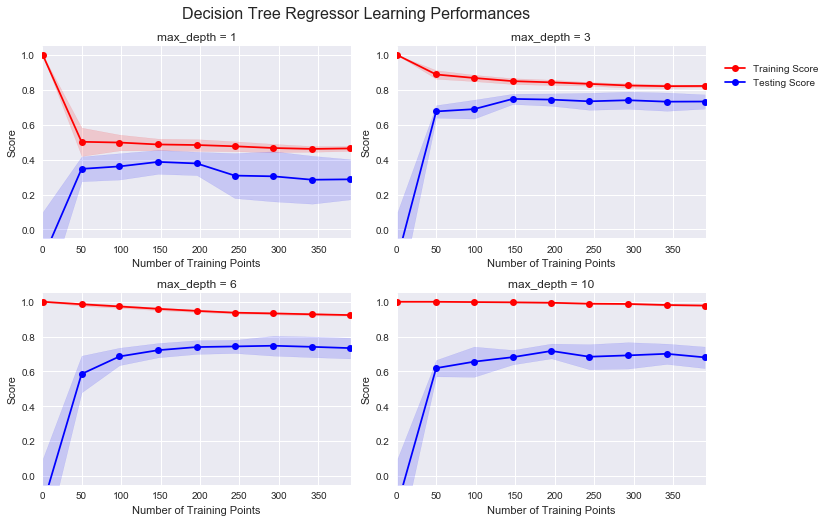

```python
# Produce learning curves for varying training set sizes and maximum depths
ModelLearning(features, prices)
```

### Learning Curves Analysis:

**- For the two last two graphs (max depths: 6 and 10):** Their training scores are very high compared to previous graphs with an advantage to the graph with max depth 10. The testing scores are very high compared to the first graph with an advantage to the graph with max depth = 6, but they still lower testing curve score of the second graph (max depth=3). The medium gap size between the training and testing curves for both graphs indicates that both models start to overfit the data.

## Complexity Curves

The following two code cells produce a graph for a decision tree model that has been trained and validated on the training data using different maximum depths from 1 to 10. The graph produces two complexity curves — one for training and one for validation. Similar to the **learning curves**, the shaded regions of both the complexity curves denote the uncertainty in those curves, and the model is scored on both the training and validation sets using the `performance_metric` function.

```python
def ModelComplexity(X, y):
    """ Calculates the performance of the model as model complexity increases.
        The learning and testing errors rates are then plotted. """

    # Create 10 cross-validation sets for training and testing
    cv = ShuffleSplit(X.shape[0], n_iter = 10,test_size = 0.2,  random_state = 337)

    # Vary the max_depth parameter from 1 to 10
    max_depth = np.arange(1,11)

    # Calculate the training and testing scores
    train_scores, test_scores = curves.validation_curve(DecisionTreeRegressor(), X, y, \
        param_name = "max_depth", param_range = max_depth, cv = cv, scoring = 'r2')

    # Find the mean and standard deviation for smoothing
    train_mean = np.mean(train_scores, axis=1)
    train_std = np.std(train_scores, axis=1)
    test_mean = np.mean(test_scores, axis=1)
    test_std = np.std(test_scores, axis=1)

    # Plot the validation curve
    plt.figure(figsize=(7, 5))
    plt.title('Decision Tree Regressor Complexity Performance')
    plt.plot(max_depth, train_mean, 'o-', color = 'r', label = 'Training Score')
    plt.plot(max_depth, test_mean, 'o-', color = 'g', label = 'Validation Score')
    plt.fill_between(max_depth, train_mean - train_std, \
        train_mean + train_std, alpha = 0.15, color = 'r')
    plt.fill_between(max_depth, test_mean - test_std, \
        test_mean + test_std, alpha = 0.15, color = 'g')

    # Visual esthetics
    plt.legend(loc = 'lower right')
    plt.xlabel('Maximum Depth')
    plt.ylabel('Score')
    plt.ylim([-0.05,1.05])
    plt.show()
```

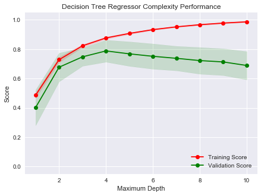

```python
# generate the complexity graph for the training data
ModelComplexity(X_train, y_train)
```

### Bias-Variance Tradeoff

- Model trained with max_depth of 1: The model suffers from high bias at this depth. Looking at the graph, we can see that both training and validation scores are low, and similar. We can say that the model is over-simplified and is not capturing the underlying relationships present in the data for both training and validation datasets.
- Model trained with max_depth of 10: The model suffers from high variance at this depth, and is overfitting on the training data. In the graph, we can see that the training score at this depth is almost equal to 1.0, while the validation score is lower, at around 0.7. The curves also seem to be diverging away from each other at this point.

# IV. Searching for the Optimal Model

In this final section of the project, we will construct a model and make a prediction on the client's feature set using an optimized model from `fit_model`.

We'll be using **Grid Search** and **Kfold from Cross Validation** to produce the optimal model.

## Grid Search:

The grid search technique is a systematic way of going through different combinations of parameter values while cross validating the results to determine the parameter combination which gives the best performance based on a error or scoring metrics.

In order to optimize a learning algorithm, we can apply grid search by specifying the parameters, and the possible values of those parameters. The grid search then returns the best parameter values for our model, after fitting the supplied data. This takes out the guess-work involved in seeking out the optimal paramter values for a classifier.

- **Advantages**: It saves time if the total number of values we want to check is **not big**. :
- **Disadvantages**: **The curse of dimensionality** it repeats the train-validation process each possible Combination. The number of combinations grows exponentially for each new Hyper parameter added to the gird.
- $N:$ The number of parameters we want to include in the grid search
- $Card(param_i)$: The number of values mentioned in grid search dictionary of the $param_i$
- $ Num_{possibilities} =$ $\prod\limits_{i=1}^{i=N} Card (param_i)$

## Cross-Validation:

The k-fold crossvalidation training technique is a way of splitting the dataset into *k* partitions of equal size, and then running *k* separate learning experiments on the training data. In each of the experiments, we chose a training set of the size of k-1 partitions, we train our model on these partitions, and evaluate the results on the remaining validation data. The results/scores for the k experiments are then averaged out.

This technique is benefitial when using grid search to optimize models because it allows us to look for parameter settings that perform well for different validation sets. If we had a single validation set, it's easy to tune a model to perform well for that specific set (and result in overfitting on the validation set in this case), while cross validation allows us to generalize the results. It allows also to use the entire data for both training and validation(testing) operations in case the dataset is not splitted earlier into training and testing sets.

We shuffle and split randomly the $Full_{data}$ into two data sets eg : 80% for $Training_{data}$ and 20% for $Testing_{data}$.

**The K-fold cross validation begins** :

**$The$ $process$**:

- We Shuffle and split the $Training_{data}$ into k equal parts($K$-$fold$).Each time we pick a new $fold_i$ from the $k$-$folds$ not already used for validation. We create a new $model_i$ .We train the $model_i$ on the $(k-1)$ parts that are different from $part_i$.We validate the $model_i$ on that $fold_i$ we picked up earlier.
- By repeating **$The$ $process$** mentioned before K times we end up by having K-different models. Each $model_i$ is trained on the (k-1) $fold_j$ ;$j$ different from $i$; of the **Training data** and validated just once on that $fold_i$ choosed earlier.By calculating the average of these k-models we end up by a **One final model** that used all the $Training_{data}$ for both learning and validating.

**End K-fold cross validation**

We test the **final model** on the $Testing_{data}$ to be sure it doesn't suffer from: **High Bias** or **High Variance**.

- **The benefits from using K-fold cross validation method with gridsearch :**

By using K-fold combined with gridsearchCV the learner will be trained and validated k-times for each possible parameters compbination. So by the end of the day we will have ($k$ $*$ $num_{combinations}$) model. The k-fold method will averages the $k_ scores$ obtained from each combination and choose the best one which has the highest score or the lower error rate as the best params of the optimal model. The **final model** will have a reduced variance because it uses all the $training_{data}$ for validation.

### Fitting a Model

Now we'll bring everything together and train a model using the **decision tree regressor algorithm**. To ensure that we are producing an optimized model, we will train the model using the grid search technique to optimize the `'max_depth'` parameter for the decision tree.

```python
def fit_model(X, y):
    """ Performs grid search over the 'max_depth' parameter for a
        decision tree regressor trained on the input data [X, y]. """

    # Create cross-validation sets from the training data

    # sklearn version 0.17: ShuffleSplit(n, n_iter=10, test_size=0.1, train_size=None, random_state=None)
    cv_sets = ShuffleSplit(X.shape[0], n_iter = 10, test_size = 0.20, random_state = 337)

    # Create a decision tree regressor object
    regressor = DecisionTreeRegressor()

    # Create a dictionary for the parameter 'max_depth' with a range from 1 to 10

    params = {'max_depth':range(1,11)}


    # Transform 'performance_metric' into a scoring function using 'make_scorer'
    scoring_fnc = make_scorer(performance_metric)

    # Create the grid search cv object --> GridSearchCV()
    # Make sure to include the right parameters in the object:
    # (estimator, param_grid, scoring, cv) which have values 'regressor', 'params', 'scoring_fnc', and 'cv_sets' respectively.
    grid = GridSearchCV(regressor, params, scoring=scoring_fnc, cv=cv_sets)

    # Fit the grid search object to the data to compute the optimal model
    grid = grid.fit(X, y)

    # Return the optimal model after fitting the data
    return grid.best_estimator_
```

### Making Predictions

Once a model has been trained on a given set of data, it can be used to make predictions on new sets of input data. In the case of a *decision tree regressor*, the model has learned *what the best questions to ask about the input data are*, and can respond with a prediction for the **target variable**.

```python
# Fit the training data to the model using grid search
reg = fit_model(X_train, y_train)

# Produce the value for 'max_depth'
print "Parameter 'max_depth' is {} for the optimal model.".format(reg.get_params()['max_depth'])
```

```
Parameter 'max_depth' is 4 for the optimal model.
```

### Predicting Selling Prices

Imagine that we were a real estate agents in the Boston area looking to use this model to help price homes owned by our clients that they wish to sell. we have collected the following information from three of our clients:

| Feature | Client 1 | Client 2 | Client 3 |
| --- | --- | --- | --- |
| Total number of rooms in home | 5 rooms | 4 rooms | 8 rooms |
| Neighborhood poverty level (as %) | 17% | 32% | 3% |
| Student-teacher ratio of nearby schools | 15-to-1 | 22-to-1 | 12-to-1 |

Let's see what prices our model will predict for these clients, and if they seem reasonable given the features.

```python
# Produce a matrix for client data
client_data = [[5, 17, 15], # Client 1
               [4, 32, 22], # Client 2
               [8, 3, 12]]  # Client 3

# Show predictions
for i, price in enumerate(reg.predict(client_data)):
    print "Predicted selling price for Client {}'s home: ${:,.2f}".format(i+1, price)
```

```
Predicted selling price for Client 1's home: $409,570.00
Predicted selling price for Client 2's home: $240,857.14
Predicted selling price for Client 3's home: $913,500.00
```

### The statistics calculated in the Data Exploration

- Minimum price: 105,000.00`$`
- Maximum price: 1,024,800.00 `$`
- Mean price: 454,342.94`$`
- Median price 438,900.00`$`
- Standard deviation of prices: 165,171.13`$`

The prices seem reasonable given the features of the homes. We can see that the highest priced home is the one which has the most of rooms, lowest neighbourhood poverty level, and the lowest student-teacher ratio, all of which make intuitive sense as discussed earlier in features-target correlations . On the contrary, the home with the lowest number of rooms, highest neighbourhood poverty level, and highest student-teacher ratio is priced as the lowest in our predictions.

# V. Conclusion: Applicability in the Real World

This finishes our project. We have built a decision tree regressor that performs reasonably well given the 3 features. But should we use this model to predict boston housing prices. I think we shouldn't for three reasons:

- The data collected in 1978 is not really relevant today due to huge change of economic and demographic factors rising population levels and changing population density of different areas,infaltion ratio...that define home's prices.
- The features present in the data are not sufficient to describe the homes of this decade. A house price depends now on the type of the home (falt house , detached , semi-detached ...) , square feet of the plot area, if it has garden or parking , transport access, proximity to city center, or neighbourhood crime rate. .
- The data collected in an urban city won't be applicable in a rural city, because the people might value different aspects of a home depending on whether they live in an urban city or a rural area. For example, a person living in a rural city might value number of rooms in a home over the proximity to the city.

**Go back to the beginning**

###### This project was completed as a part of the **Machine Learning Engineer Nanodegree** from Udacity.